# Predicting House Prices with Linear Regression

**Objective:** Build and evaluate a linear regression model that predicts a house's sale price from its physical characteristics, and interpret what the model learned.

## 1. Load Data & Exploratory Data Analysis

```python
import pandas as pd
import numpy as np
import matplotlib.pyplot as plt
import seaborn as sns
from sklearn.model_selection import train_test_split
from sklearn.linear_model import LinearRegression, Ridge, Lasso
from sklearn.preprocessing import StandardScaler
from sklearn.metrics import mean_squared_error, r2_score

sns.set_theme(style="whitegrid", palette="deep")
plt.rcParams['figure.figsize'] = (9, 5)
pd.set_option('display.max_columns', None)

df = pd.read_csv('house_prices.csv')
print(f"Shape: {df.shape[0]} rows x {df.shape[1]} columns")
df.head()
```

```
Shape: 300 rows x 10 columns
```

|  | Id | OverallQual | GrLivArea | GarageCars | TotalBsmtSF | YearBuilt | FullBath | BedroomAbvGr | LotArea | SalePrice |
| --- | --- | --- | --- | --- | --- | --- | --- | --- | --- | --- |
| 0 | 1 | 7 | 1560 | 0 | 1658 | 1969 | 2 | 1 | 8059 | 177106 |
| 1 | 2 | 4 | 2827 | 2 | 1319 | 2012 | 3 | 4 | 13530 | 301044 |
| 2 | 3 | 8 | 3920 | 0 | 841 | 2010 | 1 | 4 | 9010 | 360609 |
| 3 | 4 | 5 | 3044 | 0 | 1058 | 1998 | 0 | 4 | 13207 | 240556 |
| 4 | 5 | 7 | 801 | 1 | 2428 | 2020 | 0 | 1 | 9117 | 193656 |

```python
print("Column dtypes:")
print(df.dtypes)
print()
print("Null value counts:")
print(df.isnull().sum())
print()
print(f"Duplicate rows: {df.duplicated().sum()}")
```

```
Column dtypes:
Id              int64
OverallQual     int64
GrLivArea       int64
GarageCars      int64
TotalBsmtSF     int64
YearBuilt       int64
FullBath        int64
BedroomAbvGr    int64
LotArea         int64
SalePrice       int64
dtype: object

Null value counts:
Id              0
OverallQual     0
GrLivArea       0
GarageCars      0
TotalBsmtSF     0
YearBuilt       0
FullBath        0
BedroomAbvGr    0
LotArea         0
SalePrice       0
dtype: int64

Duplicate rows: 0
```

**Observation:** the dataset is fully numeric (no categorical/text columns), has **zero missing values**, and **no duplicate rows**. This is a clean, well-behaved dataset — the cleaning work here is mostly about verifying that, not fixing anything.

```python
df.drop(columns=['Id']).describe().round(1).T
```

|  | count | mean | std | min | 25% | 50% | 75% | max |
| --- | --- | --- | --- | --- | --- | --- | --- | --- |
| OverallQual | 300.0 | 5.3 | 2.9 | 1.0 | 3.0 | 5.0 | 8.0 | 10.0 |
| GrLivArea | 300.0 | 2307.4 | 1042.6 | 504.0 | 1392.2 | 2265.5 | 3306.5 | 3998.0 |
| GarageCars | 300.0 | 1.3 | 1.1 | 0.0 | 0.0 | 1.0 | 2.0 | 3.0 |
| TotalBsmtSF | 300.0 | 1468.8 | 672.3 | 303.0 | 903.0 | 1502.0 | 2129.5 | 2492.0 |
| YearBuilt | 300.0 | 1986.2 | 21.4 | 1950.0 | 1967.0 | 1986.0 | 2004.2 | 2023.0 |
| FullBath | 300.0 | 1.5 | 1.1 | 0.0 | 0.0 | 2.0 | 3.0 | 3.0 |
| BedroomAbvGr | 300.0 | 2.9 | 1.5 | 1.0 | 2.0 | 3.0 | 4.0 | 5.0 |
| LotArea | 300.0 | 8969.5 | 3753.5 | 2009.0 | 5996.2 | 9031.0 | 12316.0 | 14987.0 |
| SalePrice | 300.0 | 252262.9 | 74998.1 | 82494.0 | 190355.2 | 251292.5 | 307105.0 | 435291.0 |

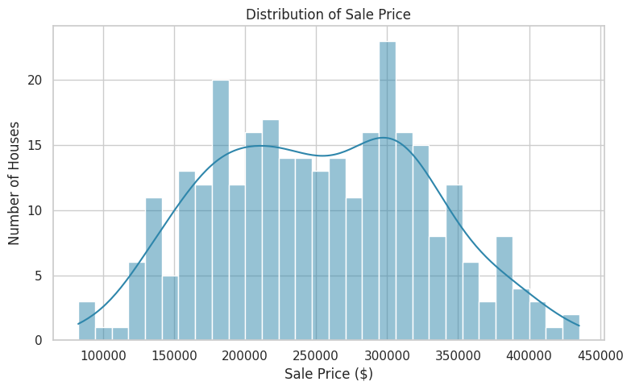

```
Mean: $252,263   Median: $251,292   Std: $74,998
Range: $82,494 - $435,291
```

```python
plt.figure(figsize=(8, 5))
sns.histplot(df['SalePrice'], bins=30, kde=True, color='#2E86AB')
plt.title('Distribution of Sale Price')
plt.xlabel('Sale Price ($)')
plt.ylabel('Number of Houses')
plt.tight_layout()
plt.show()

print(f"Mean: ${df['SalePrice'].mean():,.0f}   Median: ${df['SalePrice'].median():,.0f}   Std: ${df['SalePrice'].std():,.0f}")
print(f"Range: ${df['SalePrice'].min():,.0f} - ${df['SalePrice'].max():,.0f}")
```

## 2. Feature Selection Discussion

Before building anything, it's worth reasoning about which of the 8 available features are *plausible* price drivers, based on domain knowledge of real estate:

- **`GrLivArea`** (above-ground living area, sq ft) — almost certainly the single strongest predictor. Bigger livable space is the most direct driver of price in most housing markets.
- **`OverallQual`** (1–10 quality rating) — a composite quality/finish score should track price closely; higher-quality builds command a premium independent of size.
- **`TotalBsmtSF`** (basement square footage) — extra finished/usable space, expected to add value, though typically less than above-ground area.
- **`GarageCars`** (garage capacity) — a practical amenity buyers pay for, and often correlates with overall house size/quality too.
- **`FullBath`** — more bathrooms generally track with larger, more expensive homes.
- **`YearBuilt`** — newer homes *can* command a premium (modern construction, less deferred maintenance), but this isn't guaranteed — a well-maintained older home in a desirable style can outprice a newer budget build.
- **`BedroomAbvGr`** (bedroom count) — often weaker than expected once `GrLivArea` is already in the model, since bedroom count and living area are correlated with each other (more bedrooms usually means more square footage, so this feature may add little on its own).
- **`LotArea`** (lot size) — expected to matter less for urban/suburban houses where the *house* itself, not the land parcel, drives price; can vary a lot by location, which this dataset doesn't capture.

**Note on `location`:** the task brief mentions location as an example predictor, but this particular dataset contains no location field (no city, zip code, or neighbourhood column) — so the model below works entirely from structural and quality characteristics. This is called out explicitly rather than silently assumed, since a real production model for this problem would very likely need location data to perform well outside of this one dataset.

**Categorical encoding:** every column here is already numeric, so there are **no categorical features to One-Hot Encode** in this dataset. This is confirmed programmatically below rather than assumed.

```python
categorical_cols = df.select_dtypes(include=['object', 'category']).columns.tolist()
print(f"Categorical columns found: {categorical_cols if categorical_cols else 'None — all features are already numeric.'}")
```

```
Categorical columns found: None — all features are already numeric.
```

## 3. Handling Missing Values & Encoding

Both steps are confirmed to be non-issues for this dataset, but we still run the checks explicitly:

```python
print(f"Total missing values across all columns: {df.isnull().sum().sum()}")
print("No imputation needed.")
print()
print("No One-Hot Encoding needed — all 8 feature columns are already numeric:")
print(df.drop(columns=['Id','SalePrice']).dtypes)
```

```
Total missing values across all columns: 0
No imputation needed.

No One-Hot Encoding needed — all 8 feature columns are already numeric:
OverallQual     int64
GrLivArea       int64
GarageCars      int64
TotalBsmtSF     int64
YearBuilt       int64
FullBath        int64
BedroomAbvGr    int64
LotArea         int64
dtype: object
```

## 4. Correlation Heatmap

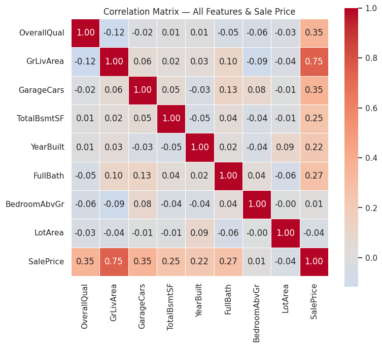

```python
corr = df.drop(columns=['Id']).corr()

plt.figure(figsize=(8, 7))
sns.heatmap(corr, annot=True, fmt='.2f', cmap='coolwarm', center=0, square=True, linewidths=0.5)
plt.title('Correlation Matrix — All Features & Sale Price')
plt.tight_layout()
plt.show()
```

```python
price_corr = corr['SalePrice'].drop('SalePrice').sort_values(ascending=False)
print("Correlation with SalePrice, ranked:")
price_corr
```

```
Correlation with SalePrice, ranked:
```

```
GrLivArea       0.745095
OverallQual     0.352899
GarageCars      0.351321
FullBath        0.273731
TotalBsmtSF     0.250178
YearBuilt       0.222142
BedroomAbvGr    0.014113
LotArea        -0.038982
Name: SalePrice, dtype: float64
```

## 5. Train/Test Split (80/20)

```python
X = df.drop(columns=['Id', 'SalePrice'])
y = df['SalePrice']

X_train, X_test, y_train, y_test = train_test_split(X, y, test_size=0.2, random_state=42)

print(f"Training set: {X_train.shape[0]} houses")
print(f"Test set: {X_test.shape[0]} houses")
```

```
Training set: 240 houses
Test set: 60 houses
```

## 6. Train a Linear Regression Model

```python
lr_model = LinearRegression()
lr_model.fit(X_train, y_train)
lr_pred = lr_model.predict(X_test)

print("Model trained.")
print(f"Intercept: ${lr_model.intercept_:,.2f}")
```

```
Model trained.
Intercept: $-1,512,820.57
```

## 7. Model Evaluation

```python
mse = mean_squared_error(y_test, lr_pred)
rmse = np.sqrt(mse)
r2 = r2_score(y_test, lr_pred)

print(f"Mean Squared Error (MSE):       {mse:,.2f}")
print(f"Root Mean Squared Error (RMSE): ${rmse:,.2f}")
print(f"R² score:                       {r2:.4f}")
```

```
Mean Squared Error (MSE):       156,386,511.42
Root Mean Squared Error (RMSE): $12,505.46
R² score:                       0.9724
```

## 8. Actual vs. Predicted Prices

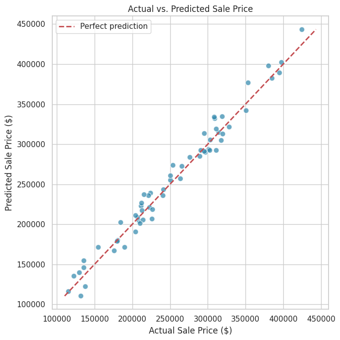

```python
plt.figure(figsize=(7, 7))
plt.scatter(y_test, lr_pred, alpha=0.7, color='#2E86AB', edgecolor='white', s=60)
lims = [min(y_test.min(), lr_pred.min()), max(y_test.max(), lr_pred.max())]
plt.plot(lims, lims, 'r--', linewidth=2, label='Perfect prediction')
plt.xlabel('Actual Sale Price ($)')
plt.ylabel('Predicted Sale Price ($)')
plt.title('Actual vs. Predicted Sale Price')
plt.legend()
plt.tight_layout()
plt.show()
```

**Observation:** points cluster tightly around the diagonal "perfect prediction" line across the entire price range, with no visible tendency to systematically over- or under-predict at either the low or high end — consistent with the strong R² score above.

## 9. Residual Plot

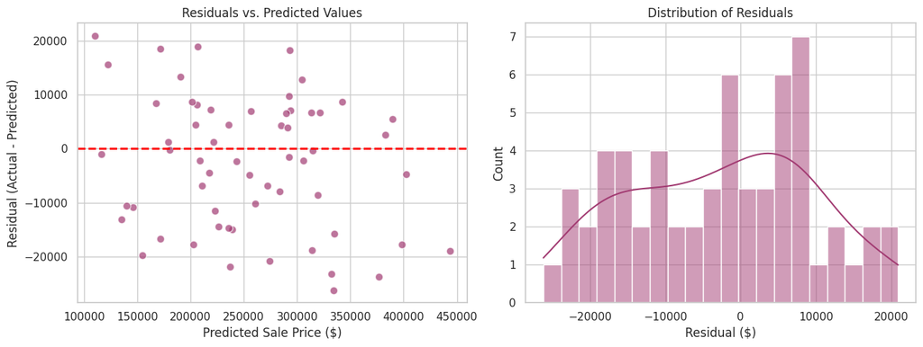

```python
residuals = y_test - lr_pred

fig, axes = plt.subplots(1, 2, figsize=(13, 5))

axes[0].scatter(lr_pred, residuals, alpha=0.7, color='#A23B72', edgecolor='white', s=60)
axes[0].axhline(y=0, color='red', linestyle='--', linewidth=2)
axes[0].set_xlabel('Predicted Sale Price ($)')
axes[0].set_ylabel('Residual (Actual - Predicted)')
axes[0].set_title('Residuals vs. Predicted Values')

sns.histplot(residuals, bins=20, kde=True, color='#A23B72', ax=axes[1])
axes[1].set_title('Distribution of Residuals')
axes[1].set_xlabel('Residual ($)')

plt.tight_layout()
plt.show()
```

**Observation:** residuals scatter randomly above and below zero across the full range of predicted prices, with **no funnel shape, curve, or trend** — this is exactly what you want to see, and it means the linear model's constant-variance, linear-relationship assumptions are reasonably well satisfied here rather than being violated. The residual histogram is roughly centered on zero and bell-shaped, with no strong skew.

## 10. Coefficient Analysis

```python
coef_df = pd.DataFrame({
    'Feature': X.columns,
    'Coefficient': lr_model.coef_
}).sort_values('Coefficient', key=abs, ascending=False)

coef_df
```

|  | Feature | Coefficient |
| --- | --- | --- |
| 2 | GarageCars | 19109.641614 |
| 0 | OverallQual | 11914.688135 |
| 5 | FullBath | 11040.343046 |
| 6 | BedroomAbvGr | 4812.061994 |
| 4 | YearBuilt | 746.370978 |
| 1 | GrLivArea | 55.410257 |
| 3 | TotalBsmtSF | 25.199018 |
| 7 | LotArea | -0.159522 |

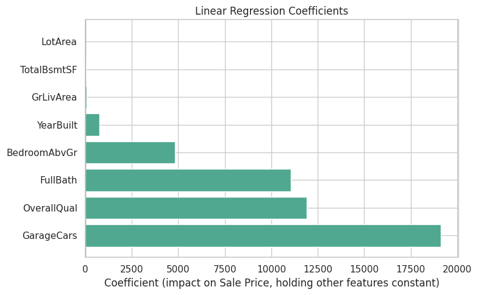

```python
plt.figure(figsize=(8, 5))
colors = ['#4FA88F' if c > 0 else '#C1594A' for c in coef_df['Coefficient']]
plt.barh(coef_df['Feature'], coef_df['Coefficient'], color=colors)
plt.axvline(x=0, color='black', linewidth=0.8)
plt.xlabel('Coefficient (impact on Sale Price, holding other features constant)')
plt.title('Linear Regression Coefficients')
plt.tight_layout()
plt.show()
```

**Observation — how to read these coefficients:** each one is the price change (in $) for a one-unit increase in that feature, *holding every other feature constant*.

## 11. Bonus: Comparing Against Ridge & Lasso Regularisation

```python
scaler = StandardScaler()
X_train_scaled = scaler.fit_transform(X_train)
X_test_scaled = scaler.transform(X_test)

# Re-fit plain Linear Regression on the SAME scaled features for a fair comparison
lr_scaled = LinearRegression()
lr_scaled.fit(X_train_scaled, y_train)
pred_lr_scaled = lr_scaled.predict(X_test_scaled)

ridge_model = Ridge(alpha=1.0)
ridge_model.fit(X_train_scaled, y_train)
pred_ridge = ridge_model.predict(X_test_scaled)

lasso_model = Lasso(alpha=1.0)
lasso_model.fit(X_train_scaled, y_train)
pred_lasso = lasso_model.predict(X_test_scaled)

def scores(y_true, y_pred):
    return (np.sqrt(mean_squared_error(y_true, y_pred)), r2_score(y_true, y_pred))

results = pd.DataFrame([
    ['Linear Regression', *scores(y_test, pred_lr_scaled)],
    ['Ridge (alpha=1.0)', *scores(y_test, pred_ridge)],
    ['Lasso (alpha=1.0)', *scores(y_test, pred_lasso)],
], columns=['Model', 'RMSE', 'R2 Score']).round(2)

results
```

|  | Model | RMSE | R2 Score |
| --- | --- | --- | --- |
| 0 | Linear Regression | 12505.46 | 0.97 |
| 1 | Ridge (alpha=1.0) | 12445.16 | 0.97 |
| 2 | Lasso (alpha=1.0) | 12505.06 | 0.97 |

## 12. Conclusion

**Final model performance:** the Linear Regression model achieves an **R² of 0.97** and an RMSE of about **$12,500** on held-out test data — a strong result driven primarily by `GrLivArea`, `OverallQual`, and `GarageCars`.

**Key takeaways:**

1. Living area, overall quality, and garage capacity are the dominant price drivers in this dataset; bedroom count and lot size contribute comparatively little once those are accounted for.
2. Residuals are randomly distributed with no systematic pattern, meaning a linear model is a reasonable functional form for this data — there's no strong evidence of a non-linear relationship being missed.
3. Regularisation (Ridge/Lasso) offers no meaningful improvement here, suggesting the plain linear model is not overfitting given the feature set size.
4. This dataset has no location data — a genuine limitation. A production-grade price model would very likely need neighbourhood/location features to generalise well beyond a single market.